# **Milestone 1**

#### Plotting the Decision Tree

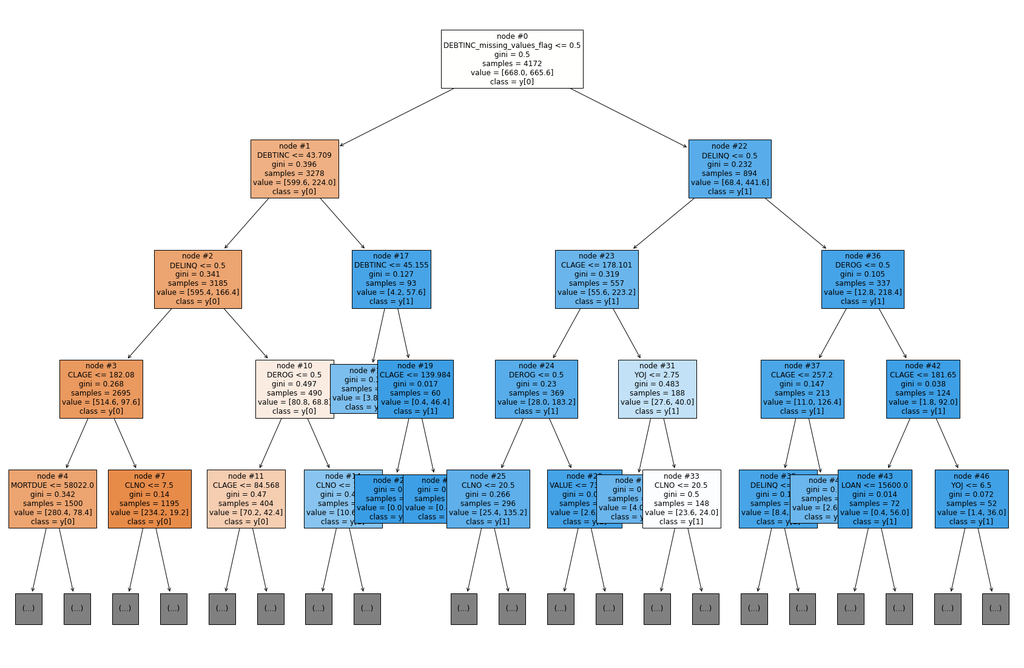

```python
# Plot the decision  tree and analyze it to build the decision rule

features = list(X.columns)

plt.figure(figsize = (30, 20))

tree.plot_tree(dtree_estimator, max_depth = 4, feature_names = features, filled = True, fontsize = 12, node_ids = True, class_names = True)

plt.show()
```

#### Deduce the business rules apparent from the Decision Tree and write them down:

**Debtinc missing value flag is used for first split and considered important in classifying the outcomes. Approx 21% of the DEBTINC variable were missing , and turned out most of them defaulted the loans. those customer whose debt to income ratio are missing are more likely to default loan compare to customer whose debt to equity are in the book. Which make sense because, for those who have no or low source of income and various small debts , it is hard to keep track of all income and debt. Among those whose debt to equity ratio are not missing, higher the DEBTINC value high chance of defaulting loan and vice versa. Customer who have lower debt to income ratio, whose Number of delinquent credit lines are less than 0.5 are more likely not to default loans. And those customer who have debt to income ratio lower than 43.709 but have DELINQ and DEROG greater than 0.5 are more likely to default loans compare to customer who have lower DEBTINC, and DELINQ and DEROG less than 0.5.**

### **Building a Random Forest Classifier**

**Random Forest is a bagging algorithm where the base models are Decision Trees.** Samples are taken from the training data and on each sample a decision tree makes a prediction.

**The results from all the decision trees are combined together and the final prediction is made using voting or averaging.**

```python
# Defining Random forest CLassifier
rf_estimator = RandomForestClassifier(class_weight = {0: 0.2, 1: 0.8}, random_state = 1)

rf_estimator.fit(x_train, y_train)
```

```
RandomForestClassifier(class_weight={0: 0.2, 1: 0.8}, random_state=1)
```

#### Checking the performance on the train dataset

```
              precision    recall  f1-score   support

           0       1.00      1.00      1.00      3340
           1       1.00      1.00      1.00       832

    accuracy                           1.00      4172
   macro avg       1.00      1.00      1.00      4172
weighted avg       1.00      1.00      1.00      4172
```

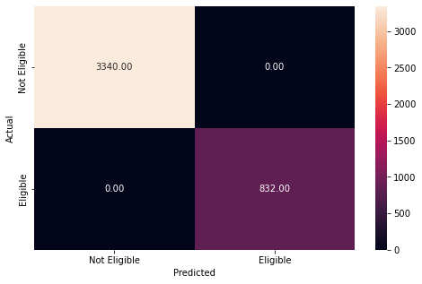

```python
#Checking performance on the training data
y_train_pred_rf = rf_estimator.predict(x_train)
metrics_score(y_train, y_train_pred_rf)
```

#### Checking the performance on the test dataset

```
              precision    recall  f1-score   support

           0       0.92      0.97      0.94      1431
           1       0.84      0.64      0.73       357

    accuracy                           0.90      1788
   macro avg       0.88      0.81      0.83      1788
weighted avg       0.90      0.90      0.90      1788
```

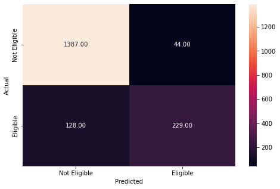

```python
# Checking performance on the test data

y_test_pred_rf = rf_estimator.predict(x_test)
metrics_score(y_test, y_test_pred_rf)
```

**Observations: This model gave 100% on all the metrics on training set but overfit on training set and gave lower metrics on test dataset. The Recall is 1 on training set but only 0.64 on test dataset.**

### **Build a Random Forest model with Class Weights**

```python
# Defining Random Forest model with class weights class_weight={0: 0.2, 1: 0.8}
# Choose the type of classifier
rf_estimator_tuned = RandomForestClassifier(class_weight = {0: 0.2, 1: 0.8}, random_state = 1)

# Grid of parameters to choose from
params_rf = {
        "n_estimators": [100, 250, 500],
        "min_samples_leaf": np.arange(1, 4, 1),
        "max_features": [0.7, 0.9, 'auto'],
}


# Type of scoring used to compare parameter combinations - recall score for class 1
scorer = metrics.make_scorer(recall_score, pos_label = 1)

# Run the grid search
grid_obj = GridSearchCV(rf_estimator_tuned, params_rf, scoring = scorer, cv = 5)

grid_obj = grid_obj.fit(x_train, y_train)

# Set the classifier to the best combination of parameters
rf_estimator_tuned = grid_obj.best_estimator_


# Fitting Random Forest model
rf_estimator_tuned.fit(x_train, y_train)
```

```
RandomForestClassifier(class_weight={0: 0.2, 1: 0.8}, min_samples_leaf=3,
                       random_state=1)
```

#### Checking the performance on the train dataset

```
              precision    recall  f1-score   support

           0       1.00      0.96      0.98      3340
           1       0.86      0.98      0.91       832

    accuracy                           0.96      4172
   macro avg       0.93      0.97      0.95      4172
weighted avg       0.97      0.96      0.96      4172
```

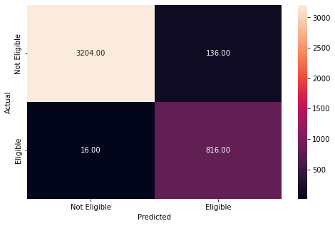

```python
# Checking performance on the train data
y_train_rf_tuned = rf_estimator_tuned.predict(x_train)
metrics_score(y_train, y_train_rf_tuned)
```

#### Checking the performance on the test dataset

```
              precision    recall  f1-score   support

           0       0.94      0.94      0.94      1431
           1       0.76      0.74      0.75       357

    accuracy                           0.90      1788
   macro avg       0.85      0.84      0.84      1788
weighted avg       0.90      0.90      0.90      1788
```

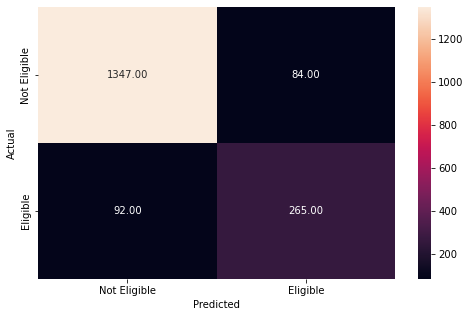

```python
# Checking performance on the test data
y_test_rf_tuned = rf_estimator_tuned.predict(x_test)
metrics_score(y_test, y_test_rf_tuned)
```

**Insight: We gave several parameters and used grid search to select best parameter to fit in the model. The performance on training data has slightly decreased, which minimize the overfit and perform better on test data compare to default random forest classifier. Recall has increased to 0.74 and precision has decreased to 0.76.**

### **Think about it:**

- Can we try different weights?
- If yes, should we increase or decrease class weights for different classes?

**Yes, we can use different weight, since we want to lower false negative , we can try to increase the weight for class1.**

### **Tuning the Random Forest**

- Hyperparameter tuning is tricky in the sense that **there is no direct way to calculate how a change in the hyperparameter value will reduce the loss of your model**, so we usually resort to experimentation. We'll use Grid search to perform hyperparameter tuning.
- **Grid search is a tuning technique that attempts to compute the optimum values of hyperparameters.**
- **It is an exhaustive search** that is performed on the specific parameter values of a model.
- The parameters of the estimator/model used to apply these methods are **optimized by cross-validated grid-search** over a parameter grid.

**n_estimators**: The number of trees in the forest.

**min_samples_split**: The minimum number of samples required to split an internal node:

**min_samples_leaf**: The minimum number of samples required to be at a leaf node.

**max_features{�auto�, �sqrt�, �log2�, 'None'}**: The number of features to consider when looking for the best split.

- If �auto�, then max_features=sqrt(n_features).
- If �sqrt�, then max_features=sqrt(n_features) (same as �auto�).
- If �log2�, then max_features=log2(n_features).
- If None, then max_features=n_features.

You can learn more about Random Forest Hyperparameters from the link given below and try to tune them

https://scikit-learn.org/stable/modules/generated/sklearn.ensemble.RandomForestClassifier.html

#### **Warning:** This may take a long time depending on the parameters you tune.

```python
# Choose the type of classifier.
# Choose the type of classifier
rf_estimator_tuned2 = RandomForestClassifier(class_weight = {0: 0.17, 1: 0.83}, random_state = 1)

# Grid of parameters to choose from
params_rf = {
        "n_estimators": [100, 250, 500, 800],
        "min_samples_leaf": np.arange(1, 7, 1),
        "max_features": [0.6, 1, 'auto'],
}


# Type of scoring used to compare parameter combinations - recall score for class 1
scorer = metrics.make_scorer(recall_score, pos_label = 1)

# Run the grid search
grid_obj = GridSearchCV(rf_estimator_tuned2, params_rf, scoring = scorer, cv = 5)

grid_obj = grid_obj.fit(x_train, y_train)

# Set the classifier to the best combination of parameters
rf_estimator_tuned2 = grid_obj.best_estimator_


# Fitting Random Forest model
rf_estimator_tuned2.fit(x_train, y_train)
```

```
RandomForestClassifier(class_weight={0: 0.17, 1: 0.83}, max_features=1,
                       min_samples_leaf=6, n_estimators=250, random_state=1)
```

#### Checking the performance on the train dataset

```
              precision    recall  f1-score   support

           0       0.98      0.89      0.93      3340
           1       0.69      0.92      0.79       832

    accuracy                           0.90      4172
   macro avg       0.83      0.91      0.86      4172
weighted avg       0.92      0.90      0.91      4172
```

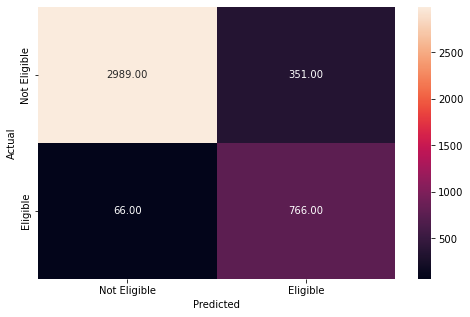

```python
# Checking performance on the training data
y_train_rf_tuned2 = rf_estimator_tuned2.predict(x_train)
metrics_score(y_train, y_train_rf_tuned2)
```

#### Checking the performance on the test dataset

```
              precision    recall  f1-score   support

           0       0.95      0.89      0.92      1431
           1       0.65      0.81      0.72       357

    accuracy                           0.87      1788
   macro avg       0.80      0.85      0.82      1788
weighted avg       0.89      0.87      0.88      1788
```

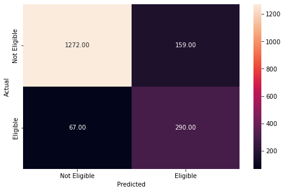

```python
# Checking performace on test dataset
y_test_rf_tuned2 = rf_estimator_tuned2.predict(x_test)
metrics_score(y_test, y_test_rf_tuned2)
```

**Insights: In this model , we have increased the weightage for class1 variable and gave higher value for parameters. Grid search found best choose higher min sample leaf parameters as best estimator compare to previous model. Compared to previous tuned model on test set, Recal has increased to 0.81 whereas precision has decreased to 0.65. which make sense as we have given more weightage to class1. F1 score for this model is 0.72, which is slightly lower than previous model.**

#### Plot the Feature importance of the tuned Random Forest

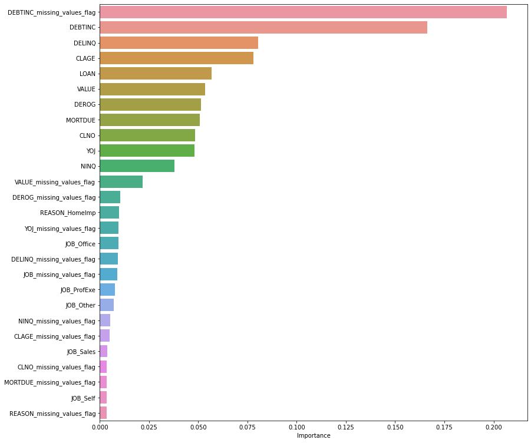

```python
# importance of features in the tree building ( The importance of a feature is computed as the
#(normalized) total reduction of the criterion brought by that feature. It is also known as the Gini importance )
importances = rf_estimator_tuned2.feature_importances_

columns = X.columns

importance_df = pd.DataFrame(importances, index = columns, columns = ['Importance']).sort_values(by = 'Importance', ascending = False)

plt.figure(figsize = (13, 13))

sns.barplot(importance_df.Importance, importance_df.index)
```

**Insight: like decision tree had the first split from DEBTINC_missing_value_flag, Random forest classifier also considered this variable most important among all. DELINQ, CAGE, LOAN, VALUE, DEROG, MORTDUE, CLNO, YOJ, NINQ are other important variables.**

### **Think about it:**

- We have only built 3 models so far, Logistic Regression, Decision Tree and Random Forest
- We can build other Machine Learning classification models like kNN, LDA, QDA or even Support Vector Machines (SVM).
- Can we also perform feature engineering and create model features and build a more robust and accurate model for this problem statement?

### **Comparing Model Performances**

```python
def get_recall_score(model,flag=True,x_train=x_train,x_test=x_test):
    '''
    model : classifier to predict values of X

    '''
    a = [] # defining an empty list to store train and test results
    pred_train = model.predict(x_train)
    pred_test = model.predict(x_test)
    train_recall = metrics.recall_score(y_train,pred_train)
    test_recall = metrics.recall_score(y_test,pred_test)
    a.append(train_recall) # adding train recall to list
    a.append(test_recall) # adding test recall to list

    # If the flag is set to True then only the following print statements will be dispayed. The default value is set to True.
    if flag == True:
        print("Recall on training set : ",metrics.recall_score(y_train,pred_train))
        print("Recall on test set : ",metrics.recall_score(y_test,pred_test))

    return a # returning the list with train and test scores
```

```python
##  Function to calculate precision score
def get_precision_score(model,flag=True,x_train=x_train,x_test=x_test):
    '''
    model : classifier to predict values of X

    '''
    b = []  # defining an empty list to store train and test results
    pred_train = model.predict(x_train)
    pred_test = model.predict(x_test)
    train_precision = metrics.precision_score(y_train,pred_train)
    test_precision = metrics.precision_score(y_test,pred_test)
    b.append(train_precision) # adding train precision to list
    b.append(test_precision) # adding test precision to list

    # If the flag is set to True then only the following print statements will be dispayed. The default value is set to True.
    if flag == True:
        print("Precision on training set : ",metrics.precision_score(y_train,pred_train))
        print("Precision on test set : ",metrics.precision_score(y_test,pred_test))

    return b # returning the list with train and test scores
```

```python
##  Function to calculate accuracy score
def get_accuracy_score(model,flag=True,x_train=x_train,x_test=x_test):
    '''
    model : classifier to predict values of X

    '''
    c = [] # defining an empty list to store train and test results
    pred_train = model.predict(x_train)
    pred_test = model.predict(x_test)
    train_acc = metrics.accuracy_score(y_train,pred_train)
    test_acc = metrics.accuracy_score(y_test,pred_test)
    c.append(train_acc) # adding train accuracy to list
    c.append(test_acc) # adding test accuracy to list

    # If the flag is set to True then only the following print statements will be dispayed. The default value is set to True.
    if flag == True:
        print("Accuracy on training set : ",metrics.accuracy_score(y_train,pred_train))
        print("Accuracy on test set : ",metrics.accuracy_score(y_test,pred_test))

    return c # returning the list with train and test scores
```

```python
# Make the list of all the model names

models = [lg, dt, dtree_estimator, rf_estimator, rf_estimator_tuned, rf_estimator_tuned2]

# defining empty lists to add train and test results
acc_train = []
acc_test = []
recall_train = []
recall_test = []
precision_train = []
precision_test = []

# looping through all the models to get the accuracy,recall and precision scores
for model in models:
     # accuracy score
    j = get_accuracy_score(model,False)
    acc_train.append(j[0])
    acc_test.append(j[1])

    # recall score
    k = get_recall_score(model,False)
    recall_train.append(k[0])
    recall_test.append(k[1])

    # precision score
    l = get_precision_score(model,False)
    precision_train.append(l[0])
    precision_test.append(l[1])
```

```python
# Mention the Model names in the list. for example 'Model': ['Decision Tree', 'Tuned Decision Tree'..... write tht names of all model built]
# Remove _________ and complete the code

comparison_frame = pd.DataFrame({'Model':[lg, dt, dtree_estimator, rf_estimator, rf_estimator_tuned, rf_estimator_tuned2],
                                          'Train_Accuracy': acc_train,
                                          'Test_Accuracy': acc_test,
                                          'Train_Recall': recall_train,
                                          'Test_Recall': recall_test,
                                          'Train_Precision': precision_train,
                                          'Test_Precision': precision_test})
comparison_frame
```

|  | Model | Train_Accuracy | Test_Accuracy | Train_Recall | Test_Recall | Train_Precision | Test_Precision |
| --- | --- | --- | --- | --- | --- | --- | --- |
| 0 | LogisticRegression() | 0.803212 | 0.807047 | 0.028846 | 0.047619 | 0.648649 | 0.772727 |
| 1 | DecisionTreeClassifier(class_weight={0: 0.2, 1... | 1.000000 | 0.878076 | 1.000000 | 0.630252 | 1.000000 | 0.723473 |
| 2 | DecisionTreeClassifier(class_weight={0: 0.2, 1... | 0.870805 | 0.857942 | 0.792067 | 0.739496 | 0.642927 | 0.621176 |
| 3 | (DecisionTreeClassifier(max_features='auto', r... | 1.000000 | 0.903803 | 1.000000 | 0.641457 | 1.000000 | 0.838828 |
| 4 | (DecisionTreeClassifier(max_features='auto', m... | 0.963567 | 0.901566 | 0.980769 | 0.742297 | 0.857143 | 0.759312 |
| 5 | (DecisionTreeClassifier(max_features=1, min_sa... | 0.900048 | 0.873602 | 0.920673 | 0.812325 | 0.685765 | 0.645880 |

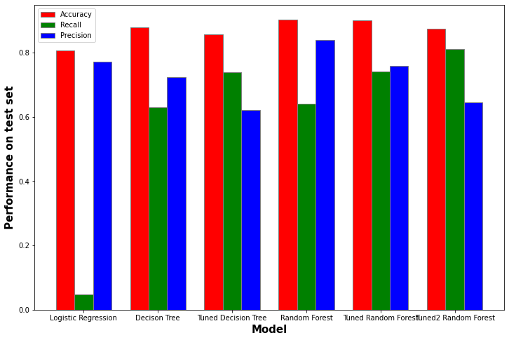

```python
# set width of bar
barWidth = 0.25
fig = plt.subplots(figsize =(12, 8))

# set height of bar
Accuracy = comparison_frame.Test_Accuracy
Recall = comparison_frame.Test_Recall
Precision = comparison_frame.Test_Precision

# Set position of bar on X axis
br1 = np.arange(len(Accuracy))
br2 = [x + barWidth for x in br1]
br3 = [x + barWidth for x in br2]

# Make the plot
plt.bar(br1, Accuracy, color ='r', width = barWidth,
        edgecolor ='grey', label ='Accuracy')
plt.bar(br2, Recall, color ='g', width = barWidth,
        edgecolor ='grey', label ='Recall')
plt.bar(br3, Precision, color ='b', width = barWidth,
        edgecolor ='grey', label ='Precision')

# Adding Xticks
plt.xlabel('Model', fontweight ='bold', fontsize = 15)
plt.ylabel('Performance on test set', fontweight ='bold', fontsize = 15)
plt.xticks([r + barWidth for r in range(len(Accuracy))],
        ['Logistic Regression', 'Decison Tree', 'Tuned Decision Tree', 'Random Forest', 'Tuned Random Forest', 'Tuned2 Random Forest'])

plt.legend()
plt.show()
```

**1. Refined insights -** What are the most meaningful insights from the data relevant to the problem?

**2. Comparison of various techniques and their relative performance -** How do different techniques perform? Which one is performing relatively better? Is there scope to improve the performance further?

**3. Proposal for the final solution design -** What model do you propose to be adopted? Why is this the best solution to adopt?